# Master Project

SID: 500505887

2023-11-06

# 1 Data Wrangling

## 1.1 Libraries

```r
library(tidyverse)
library(here)      #
library(readxl)
library(janitor)
library(stringr)
library(tidyr)
library(dplyr)
library(naniar)
library(ggplot2)
library(knitr)
library(kableExtra)
library(purrr)
library(moments)
library(bestNormalize)
library(car)
library(caret)
library(pROC)
library('finalfit')
library(gridExtra)
library(grid)
```

## 1.2 Functions

### 1.2.1 Label variables as continuous and categorical

```r
get_type <- function(dict)
{
  #dict <- dict_nutr
  var_names <- unique(dict$variable_name)
  var_type  <- c()
  for (j in 1:length(var_names))
  {
    # Get all dictionary lines corresponding to a varible
    # (a block of lines)
    dict_block <- dict %>%
      filter(variable_name==var_names[j])

    # Take all of the characters in a block, paste them
    # together and make all characters lower case
    block_string <- dict_block %>%
      select(-variable_name) %>%
      as.matrix() %>%
      as.vector() %>%
      paste(collapse="") %>%
      tolower()

    # Assign variable if we can find the word "continuous"
    # in the block otherwise assume that it is "categorical"
    var_type[j] <- block_string %>%
      str_detect("continuous") %>%
      ifelse("continuous","categorical")
  }
  return(var_type)
}
```

### 1.2.2 Split the description variable in the data dictionary into value and meaning columns

(* Modified from given)

```r
get_my_special_value_meanings <- function(dict) {
  special <- tibble(variable_name = c(),
                    value = c(),
                    meaning = c())

  for (i in 1:nrow(dict)) {
    variable <- dict$variable_name[i]
    description <- tolower(dict$description[i])  # Convert description to lowercase

    # Check if description contains "continuous"
    if (grepl("continuous", description)) {
      next  # Skip entries with "continuous" in description
    }

    # Check if description starts with a number followed by a period and space
    if (grepl("^\\d+\\. ", description)) {
      # Extract value and meaning using pattern matching
      values <- str_match(description, "^(\\d+\\. )(.*)")
      value <- values[2]
      meaning <- values[3]

      result <- tibble(variable_name = variable,
                       value = value,
                       meaning = meaning)

      special <- bind_rows(special, result)
    } else {
      # If description doesn't follow the pattern, treat the whole description as meaning
      result <- tibble(variable_name = variable,
                       value = NA,
                       meaning = description)

      special <- bind_rows(special, result)
    }
  }

  return(special)
}
```

Split the description variable in the data dictionary into value and meaning columns (* Original)

```r
get_special_value_meanings <- function(dict)
{
  var_names <- unique(dict$variable_name)
  special   <- tibble(variable_name=c(),
                      value=c(),
                      meaning=c())

  for (j in 1:length(var_names))
  {
    # Get a block of values from the dictionary
    block <-  dict %>%
      filter(variable_name==var_names[j])

    if (nrow(block)>1) {
      # Split  the descrition into value/meaning pairs
      special_block <- block[-1,-c(3:ncol(block))] %>%
        dplyr::filter(!grepl("continuous",tolower(description))) %>%
        separate(col=2,
                 sep="[.]",
                 into=c("value","meaning")) %>%
        mutate(value=as.numeric(value),
               meaning=tolower(str_trim(meaning)))

      # append these to a block of special value/meaning pairs
      special <- bind_rows(special, special_block)
    }
  }
  return(special)
}
```

### 1.2.3 Label all categorical variables and convert them to factors in R.

```r
categorical_to_factor <- function(types, proc)
{
  var_names <- colnames(proc)
  for (i in 1:length(var_names))
  {
    # Extract the inferred variable type from the types tibble
    var_type <- types %>%
      filter(variable_name==var_names[i]) %>%
      select(variable_type) %>%
      as.character()

    # If the type is categorical turn the variable into a factor
    if (var_type=="categorical") {
      proc[[var_names[i]]] <- as.factor(proc[[var_names[i]]])
    }
  }
  return(proc)
}
```

### 1.2.4 Convert raw data to technically correct data

```r
miss_defs <- c("Did not proceed to Biomedical component",
                     "Measurement not taken - equipment faulty",
                     "Measurement not taken - other reason",
                     "Measurement not taken - refusal",
                     "None of these apply",
                     "Not applicable",
                     "Not collected",
                     "Not currently on a diet",
                     "Not determined",
                     "Not known",
                     "Not known if currently on a diet",
                     "Not measured",
                     "Not reported",
                     "Not used",
                     "Not stated")
raw_to_tech <- function(proc, special, types)
{
  var_names <- colnames(proc)
  for (j in 1:length(var_names))
  {
    var_val <- var_names[j]
    specials <- special %>%
      filter(variable_name==var_val)
    if (nrow(specials)>0)
    {
      ind <- which(var_names==var_val)
      var_miss_str  <- paste0(var_val,"_MISS")
      var_miss_reas <- rep("observed",nrow(proc))
      var_vals      <- proc[,ind]
      var_type <- types %>%
        filter(variable_name==var_val) %>%
        select(variable_type) %>%
        as.character()
      if (var_type=="continuous") {
        for (i in 1:length(var_vals)) {
          if (var_vals[i] %in% specials$value) {
            ind2 <- which(var_vals[i]==specials$value)
            var_vals[i]      <- NA
            var_miss_reas[i] <- specials[ind2,3] %>% as.character()
          }
        }
      }
      if (var_type=="categorical") {
        for (i in 1:length(var_vals)) {
          spec_val  <- specials$value
          spec_meam <- specials$meaning
          if (var_vals[i] %in% spec_val)
          {
            var_mean <- spec_meam[var_vals[i] == spec_val]
            if (var_mean %in% miss_defs) {
              var_vals[i]      <- NA
              var_miss_reas[j] <- var_mean
            }
          } else {
            var_vals[i]      <- NA
            var_miss_reas[i] <- "unknown"
          }
        }
      }
      if (any(is.na(var_vals))) {
        proc[,ind] <- var_vals
        proc$dummy <- var_miss_reas
        colnames(proc)[ncol(proc)] <- var_miss_str
      }
    }
  }
  return(proc)
}
```

## 1.3 Technically correct pipeline

```r
#read in raw data
raw_biom <- read.csv(here("data","AHS11biomedical.csv"), header=TRUE)
raw_nutr <- read.csv(here("data","AHS11nutrient.csv"), header=TRUE)
raw_food <- read.csv(here("data","AHS11food.csv"), header=TRUE)

quiet_read <- purrr::quietly(readxl::read_excel) # returns [result, output, messages, warning] of a function

# read in dics for raw data
dict_biom <- quiet_read(here("data","nutmstatDataItems2019.xlsx"),sheet=1)$result
dict_nutr <- quiet_read(here("data","nutmstatDataItems2019.xlsx"),sheet=2)$result
dict_food <- quiet_read(here("data","nutmstatDataItems2019.xlsx"),sheet=3)$result

# clean var names
dict_biom <- dict_biom %>% janitor::clean_names() %>% rename(extra=x3)
dict_nutr <- dict_nutr %>% janitor::clean_names() %>% rename(extra1=x3,extra2=x4)
dict_food <- dict_food %>% janitor::clean_names() %>% rename(extra=x3)

# remove empty rows
dict_biom <- dict_biom %>% janitor::remove_empty("rows")
dict_nutr <- dict_nutr %>% janitor::remove_empty("rows")
dict_food <- dict_food %>% janitor::remove_empty("rows")

# Create datasets with human readable versions of the variable names
biom_readable <- dict_biom %>%
  filter(!is.na(variable_name))
nutr_readable <- dict_nutr %>%
  filter(!is.na(variable_name)) %>%
  distinct() # Removes 1 duplicate
food_readable <- dict_food %>%
  filter(!is.na(variable_name)) %>%
  distinct()

#Fill in blanks in the variable names
dict_biom <- dict_biom %>% tidyr::fill(variable_name)
dict_nutr <- dict_nutr %>% tidyr::fill(variable_name)
dict_food <- dict_food %>% tidyr::fill(variable_name)

var_names_biom <- unique(dict_biom$variable_name)
var_names_nutr <- unique(dict_nutr$variable_name)
var_names_food <- unique(dict_food$variable_name)

# Try to infer the data types from the data dictionary
tib1 <- tibble(variable_type=get_type(dict_biom))
tib2 <- tibble(variable_type=rep("continuous",nrow(nutr_readable)))
tib3 <- tibble(variable_type=get_type(dict_food))

# Create a new tibble that takes the readable tibble,
# appends the variable type, and do some minor fixing
types_biom <- bind_cols(biom_readable, tib1) %>%
  mutate(variable_type=ifelse(var_names_biom%in%c("ABSPID","ABSHID"), "string",variable_type))

types_nutr <- bind_cols(nutr_readable, tib2) %>%
  mutate(variable_type=ifelse(variable_name%in%c("ABSPID","ABSHID"), "string",variable_type))

types_food <- bind_cols(food_readable, tib3) %>%
  mutate(variable_type=ifelse(variable_name%in%c("ABSPID","ABSHID"), "string",variable_type))
#============================================================
# BIOM DATA
# Made modification to get_special_value_meanings: descriptions for some categorical values (e.g., GLUCFREB) weren't translating correctly (*)
special_biom_new <- get_my_special_value_meanings(dict_biom)
special_biom_new$value <- gsub("\\.", "", special_biom_new$value)  # Remove all dots from the 'value' column

# Remove descriptions
special_biom_new <- special_biom_new %>%
  filter(!is.na(value))

# Convert values to numeric
special_biom_new$value = as.numeric(special_biom_new$value)
#============================================================
#Trying my modified function with the other raw (found it doesnt work):
# special_nutr <- get_my_special_value_meanings(dict_nutr) %>% na.omit()
# special_food <- get_my_special_value_meanings(dict_food) %>% na.omit()
#============================================================
#Using Johns with raw nutr and fodd:
special_nutr <- get_special_value_meanings(dict_nutr) %>% na.omit()
special_food <- get_special_value_meanings(dict_food) %>% na.omit()
#============================================================
# PATCH 3 (*)
miss_defs = tolower(miss_defs) #Adds _MISS vars for COMBCODE and EATOCC
#============================================================

proc_biom <- categorical_to_factor(types_biom,raw_biom)
proc_nutr <- categorical_to_factor(types_nutr,raw_nutr)
proc_food <- categorical_to_factor(types_food,raw_food)

# Convert biom data to technically correct
tech_biom <- raw_to_tech(proc_biom, special_biom_new, types_biom)
tech_nutr <- raw_to_tech(proc_nutr, special_nutr, types_nutr)
tech_food <- raw_to_tech(proc_food, special_food, types_food)
```

## 1.4 Patches

### 1.4.1 PATCH 1 - FIX EXERCISE COLUMNS

```r
# Convert 'phys', 'mod', and 'vig' columns to numeric and create corresponding '_MISS' columns
# deliberately keeping 9996 and 9999 and desc in _MISS vars because could need them later

# Convert 'phys', 'mod', and 'vig' columns to numeric and create corresponding '_MISS' columns
tech_biom_mod <- tech_biom %>%
  mutate(
    phys_num = as.numeric(as.character(EXLWTBC)),
    mod_num = as.numeric(as.character(EXLWMBC)),
    vig_num = as.numeric(as.character(EXLWVBC)),
    phys_MISS = ifelse(phys_num %in% c(9996, 9999), as.character(phys_num), "observed"),
    mod_MISS = ifelse(mod_num %in% c(9996, 9999), as.character(mod_num), "observed"),
    vig_MISS = ifelse(vig_num %in% c(9996, 9999), as.character(vig_num), "observed")
  )

# Replace entries in 'phys', 'mod', and 'vig' columns with NA where values are 9996 or 9999
tech_biom_mod$phys_num[tech_biom_mod$phys_num %in% c(9996, 9999)] <- NA
tech_biom_mod$mod_num[tech_biom_mod$mod_num %in% c(9996, 9999)] <- NA
tech_biom_mod$vig_num[tech_biom_mod$vig_num %in% c(9996, 9999)] <- NA


tech_biom = tech_biom_mod %>% select(
  -c(EXLWTBC, EXLWMBC, EXLWVBC)
)
```

### 1.4.2 PATCH 2 - Link Food Class to Food data

```r
df <- tech_food %>%
  select(
    FOODCODC,
    FIVDIG,
    THRDIG,
    TWDIG
  ) %>%
  mutate(
    FOODCODC = as.character(FOODCODC),
    FIVDIG = as.character(FIVDIG),
    THRDIG = as.character(THRDIG),
    TWDIG = as.character(TWDIG)
  )

dict_food_class = quiet_read(here("data","nutmstatDataItems2019.xlsx"),sheet=4)$result


# Shift the column names to the values in the  row
colnames(dict_food_class) <- as.character(dict_food_class[2, ])

# Remove the first row after assigning column names
dict_food_class <- dict_food_class[-c(1,2), ]
dict_food_class <- dict_food_class %>% janitor::clean_names()

# Replace values for FOODCODC
df <- df %>%
  left_join(dict_food_class, by = c("FOODCODC" = "category_code")) %>%
  mutate(FOODCODC = category_label) %>%
  select(-category_label)  # remove the joined 'category_label' column

# Replace values for FIVDIG
df <- df %>%
  left_join(dict_food_class, by = c("FIVDIG" = "category_code")) %>%
  mutate(FIVDIG = category_label) %>%
  select(-category_label)

# Replace values for THRDIG
df <- df %>%
  left_join(dict_food_class, by = c("THRDIG" = "category_code")) %>%
  mutate(THRDIG = category_label) %>%
  select(-category_label)

# Replace for TWDIG
df <- df %>%
  left_join(dict_food_class, by = c("TWDIG" = "category_code")) %>%
  mutate(TWDIG = category_label) %>%
  select(-category_label)

# Replace original columns in tech_food with the ones from df
tech_food <- tech_food %>%
  mutate(
    FOODCODC = df$FOODCODC,
    FIVDIG = df$FIVDIG,
    THRDIG = df$THRDIG,
    TWDIG = df$TWDIG
  )
```

### 1.4.3 PATCH 3 - FIXING FOOD DATA

Found that expected _MISS variables are not present in tech_food (corrected by tolower()) (*) - Other expected _MISS vars (derived from types_food e.g., psaltadd, density, etc.) are not present:

```r
# checking if all vars in type_food are present in raw data (found that PSALTADD is not present)
vars_in_types_food = subset(types_food, !is.na(description))$variable_name
vars_in_raw = colnames(raw_food)
#setdiff(vars_in_types_food, vars_in_raw)
#setdiff(vars_in_raw, vars_in_types_food)
# Can see that the expected vars are not actually present in the raw data +
 #there are 4 redundant cols at the end of raw_food - need to remove these.
tech_food = tech_food %>% select(-setdiff(vars_in_raw, vars_in_types_food))
```

### 1.4.4 PATCH 4 - MERGING BIOM, NUTR and FOOD

Biom and nutrient can be joined by ABSPID as there are no duplicate entries for PID

```r
#length(unique(tech_biom$ABSPID))
#length(unique(tech_nutr$ABSPID))

biom_nutr_raw = tech_biom %>%
  full_join(tech_nutr, by = "ABSPID")
```

FOOD contains multiple entries per person (ABSPID) so its not a trivial join. Im thinking I create a list object for each ABSPID that contains all the information for that ABSPID. I.e., Create a column in biom_nutr_raw called FOOD_data ( and for each ABSPID it will contain all info for that ABSPID in tech_food

```r
# Split the tech_food dataframe into a list based on ABSPID
list_data <- with(tech_food, split(tech_food, ABSPID))

# Create a new dataframe with unique ABSPID and corresponding list_data
list_df <- data.frame(ABSPID = names(list_data), FOOD_DATA = I(list_data))

# Merge with biom_nutr_raw
biom_nutr_food <- merge(biom_nutr_raw, list_df, by = "ABSPID", all.x = TRUE)

# If some ABSPIDs from biom_nutr_raw don't have corresponding data in tech_nutr,
# the FOOD_DATA column for those ABSPIDs will have NAs. If you want to replace NAs with empty lists, you can do:
biom_nutr_food$FOOD_DATA[sapply(biom_nutr_food$FOOD_DATA, is.null)] <- I(list(data.frame()))

# Could further split into daynum for example (there are 2 levels)
```

### 1.4.5 PATCH 5 - LINK ABORIGINAL AND ISLANDER COHORT

Note that 230ish variables are common between the two datasets. Some variables that are not in the above data dictionary (aboriginal/dictionary.csv) can be found in the numstat dict file (biom, food, nutr, food_class)

```r
raw_abor = read.csv(here("data/aboriginal","aboriginal_cohort.csv"), header=TRUE)
dict_abor <- read.csv(here("data/aboriginal","dictionary.csv"),header=TRUE)
```

### 1.4.6 PATCH 6 - FIX AGE COL NAME (realised that even though only household id is used to identify, they are still individuals (not households; same household id is repeated for different individuals) - might have to check other variables)

```r
raw_abor$AGEC = raw_abor$AGEEC

# Function to find descriptions
find_descriptions <- function(col_names, dictionaries) {
  descriptions <- character(0)

  for (col_name in col_names) {
    for (dict in dictionaries) {
      match_row <- match(col_name, dict$variable_name)
      if (!is.na(match_row)) {
        descriptions <- c(descriptions, dict$description[match_row])
        break  # Break out of the inner loop once a match is found
      }
    }
  }

  return(descriptions)
}

# Find colnames in common between biom_nutr_food and aboriginal/islander and extract descriptions

abor_cols = colnames(raw_abor)
df_cols = colnames(biom_nutr_food)
food_cols = colnames(tech_food)
common_df_abor_cols = intersect(df_cols, abor_cols)
common_food_abor_cols = intersect(food_cols, abor_cols)
#only ABSHID (i.e., food data (in biom_nutr_food) not relev for aboriginal cohort)
descriptions1 <- find_descriptions(common_df_abor_cols, list(types_biom, types_nutr))
descriptions2 <- find_descriptions(common_food_abor_cols, list(types_food))
```

INDGSTAT not in raw data! need another way to classify as indigenous.

Turns out culture vars arent in raw data. Looking at the dictionary.csv file more carefully, i noticed ‘Type of Aboriginal and …Islander household’ which led me to the ‘household level’ sheet in the dic

can use household level data to determine number of aboriginal/islander in each home (only ABSHID is provided in raw data so makes sense) - rmk: theres a lot of data there e.g., household_type etc that may help with accuracy later on

```r
# set up household dictionary for indigenous cohort (might be needed later)
dict_abor <- read_excel(here("data/aboriginal", "australian aboriginal and torres strait islander health survey data item list.xls"), sheet = 4, skip = 4) # skip to where relevant in sheet
dict_abor = dict_abor %>% select (
  variable_name = `SAS name`,
  `Items & categories`,
  `Main population`
)
dict_abor <- dict_abor %>% janitor::remove_empty("rows")
abor_readable <- dict_abor %>%
  filter(!is.na(variable_name))
dict_abor <- dict_abor %>% tidyr::fill(variable_name)
var_names_abor <- unique(dict_abor$variable_name)
tib4 <- tibble(variable_type=get_type(dict_abor))
types_abor <- bind_cols(abor_readable, tib4)

# Subset id and number of aboriginal/islander in house

df_abor = raw_abor %>% select(
  ABSHID,
  NOATSIHH
)

# step 1: clean cols that are in biom data
biom_cols = colnames(tech_biom)
common_biom_abor_cols = intersect(biom_cols, abor_cols)
common_biom_abor_cols = c("ABSHID", common_biom_abor_cols)
biom_abor_df = raw_abor[, common_biom_abor_cols]
tech_biom_abor = raw_to_tech(biom_abor_df, special_biom_new, types_biom)
# step 2: clean cols that are in nutr data
nutr_cols = colnames(tech_nutr)
common_nutr_abor_cols = intersect(nutr_cols, abor_cols)
common_nutr_abor_cols = c(common_nutr_abor_cols, "ABSHID")
nutr_abor_df = raw_abor[, common_nutr_abor_cols]
tech_nutr_abor = raw_to_tech(nutr_abor_df, special_nutr, types_nutr)
# step 3: full merge (can filter later if needed)
tech_abor = merge(tech_biom_abor, tech_nutr_abor, by = "ABSHID", all = TRUE)

# Now need to join household_number var
tech_abor = merge(tech_abor, df_abor, by = "ABSHID", all = TRUE)
```

### 1.4.7 PATCH 7: ADD PROXY ABSPID TO ABORIGINAL DATA

```r
tech_abor = tech_abor %>% mutate(ABSPID = row_number())
```

## 1.5 Saving/Clearing Environment

# 2 CVD Risk prevalence in Cohorts

## 2.1 Setup

```r
# Merge biom data for both groups
biom_ind = types_biom$variable_name[types_biom$variable_name %in% colnames(tech_abor)]
biom_nonind = types_biom$variable_name[types_biom$variable_name %in% colnames(biom_nutr_food)]

names = intersect(biom_ind, biom_nonind)
# subset
ind_biom = tech_abor %>% select(all_of(names)) %>% mutate(group = 'Indigenous')
nonind_biom = biom_nutr_food %>% select(all_of(names)) %>% mutate(group = 'Non-Indigenous')

for (col_name in names(ind_biom)) {
  # Skip the 'group' column as it doesn't need to be changed
  if (col_name != "group") {
    target_class <- class(nonind_biom[[col_name]])

    # Check if the classes are different
    if (class(ind_biom[[col_name]]) != target_class) {
      # Coerce to the target class
      if (target_class == "factor") {
        ind_biom[[col_name]] <- as.factor(ind_biom[[col_name]])
      } else if (target_class == "numeric") {
        ind_biom[[col_name]] <- as.numeric(as.character(ind_biom[[col_name]]))  # Convert to character first to avoid potential issues
      } else if (target_class == "integer") {
        ind_biom[[col_name]] <- as.integer(as.character(ind_biom[[col_name]]))  # Convert to character first
      } else if (target_class == "character") {
        ind_biom[[col_name]] <- as.character(ind_biom[[col_name]])
      }  # Add more cases if there are more data types you need to handle
    }
  }
}

# Convert variables in nonind_biom to match those in ind_biom
for (var in names(ind_biom)) {
  if (is.integer(ind_biom[[var]])) {
    nonind_biom[[var]] <- as.integer(as.character(nonind_biom[[var]]))
  }
  else if (is.numeric(ind_biom[[var]])) {
    nonind_biom[[var]] <- as.numeric(as.character(nonind_biom[[var]]))
  }
}


#Transcribe factor levels from dictionary to df:

# Combine the dataframes
df = rbind(ind_biom, nonind_biom)
df$group = as.factor(df$group)
df = df %>% filter(AGEC >=18)

for (var in names(df)) {
  # Check the type of the variable from types_biom
  var_type <- subset(types_biom, variable_name == var)$variable_type

  if (length(var_type) == 0) {
    next  # skip if the variable is not found in types_biom
  }

  if (var_type == "categorical") {
    # Fetch the descriptions for the variable from dict_biom
    descriptions <- subset(dict_biom, variable_name == var)$description

    # Extract codes from the descriptions
    codes <- as.numeric(sub("([0-9]+)\\..*", "\\1", descriptions))

    # Exclude the rows with NA (which would be the ones that don't have codes)
    valid_rows <- !is.na(codes)
    descriptions <- descriptions[valid_rows]
    codes <- codes[valid_rows]

    # The first valid entry after filtering might be a definition, so we should check and remove it
    if(!grepl("^[0-9]+\\.", descriptions[1])){
      descriptions <- descriptions[-1]
      codes <- codes[-1]
    }

    # Create a named vector to map the levels
    level_mapping <- setNames(descriptions, codes)

    # Convert the variable to a factor and set the levels
    df[[var]] <- factor(df[[var]], levels = as.character(codes), labels = descriptions)
  }
}
str(df)
```

```
## 'data.frame':    15737 obs. of  42 variables:
##  $ ABSPID  : chr  "1" "2" "3" "4" ...
##  $ ABSHID  : chr  "INP13B1000001" "INP13B1000002" "INP13B1000002" "INP13B1000002" ...
##  $ BMISC   : num  26.6 33.3 33.3 33.3 33.3 ...
##  $ AGEC    : int  27 27 27 27 27 65 43 43 43 43 ...
##  $ PHDCMWBC: num  96 111 111 111 111 ...
##  $ ADTOTSE : int  NA NA NA NA NA NA NA NA NA NA ...
##  $ BDYMSQ04: Factor w/ 6 levels "0. Not applicable",..: NA NA NA NA NA NA NA NA NA NA ...
##  $ DIASTOL : int  77 68 68 68 68 81 NA NA NA NA ...
##  $ DIETQ12 : Factor w/ 6 levels "0. Not applicable",..: 3 2 2 2 2 2 3 3 3 3 ...
##  $ DIETQ14 : Factor w/ 6 levels "0. Not applicable",..: 3 2 2 2 2 NA 3 3 3 3 ...
##  $ DIETQ5  : Factor w/ 9 levels "0. Not applicable",..: 2 8 8 8 8 2 8 8 8 8 ...
##  $ DIETQ8  : Factor w/ 9 levels "0. Not applicable",..: 2 2 2 2 2 8 2 2 2 2 ...
##  $ DIETRDI : Factor w/ 4 levels "0. Not applicable",..: 3 3 3 3 3 3 3 3 3 3 ...
##  $ SABDYMS : Factor w/ 7 levels "0. Not applicable",..: 2 2 2 2 2 2 2 2 2 2 ...
```

[output cut: 28 more lines]

## 2.2 Definitions

Create target variables and corresponding criteria that will be used to define CVD risk (labels and corresponding ranges/criteria provided by Nutrition students)

```r
# Filter and create flags
df <- df %>%
  mutate(
    # Obesity conditions
    Obesity = case_when(
      is.na(BMISC) | is.na(SEX) | is.na(PHDCMWBC) ~ NA_character_,
      BMISC > 30 ~ "Obese",
      (SEX == "1. Male" & PHDCMWBC > 102) | (SEX == "2. Female" & PHDCMWBC > 88) ~ "Obese",
      TRUE ~ "Not Obese"
    ),

    # Hypertension conditions
    Hypertension = case_when(
      is.na(SYSTOL) | is.na(DIASTOL) ~ NA_character_,
      SYSTOL > 140 | DIASTOL > 90 ~ "Hypertensive",
      SYSTOL <= 140 & DIASTOL <= 90 ~ "Non-Hypertensive",
    ),

    # Diabetes condition
    Diabetes = case_when(
      is.na(DIAHBRSK) ~ NA_character_,
      DIAHBRSK %in% c("2. At risk of diabetes - HbA1c 6.0 - 6.4 %", "3. Indicates diabetes - HbA1c greater than or equal to 6.5%") ~ "Diabetic or at risk",
      DIAHBRSK == "1. Normal - HbA1c <6.0%" ~ "Non Diabetic",
    ),

    # ApoB condition
    ApoB = case_when(
      is.na(APOBNTR) ~ NA_character_,
      APOBNTR == "1. Normal ApoB" ~ "Normal ApoB",
      APOBNTR == "2. Abnormal ApoB" ~ "Abnormal ApoB",
    ),

    # Dyslipidemia conditions
    Dyslipidemia = case_when(
      # Conditions for Dyslipidemia
      (SEX == "1. Male" & HDLCHREB == "1. Less than 1.0") | (SEX == "2. Female" & HDLCHREB %in% c("1. Less than 1.0", "2. 1.0 to less than 1.3")) ~ "Dyslipidemia",
      !is.na(LDLRESB) & LDLRESB %in% c("06. 3.5 to less than 4.0", "07. 4.0 to less than 4.5", "08. 4.5 or more") ~ "Dyslipidemia",
      !is.na(TRIGRESB) & TRIGRESB %in% c("05. 2.0 to less than 2.5", "2.5 to less than 3.0", "07. 3.0 or more") ~ "Dyslipidemia",

      # If no conditions are met and there are no missing variables
      (is.na(SEX) | is.na(HDLCHREB) | is.na(LDLRESB) | is.na(TRIGRESB)) &
      !((SEX == "1. Male" & HDLCHREB == "1. Less than 1.0") | (SEX == "2. Female" & HDLCHREB %in% c("1. Less than 1.0", "2. 1.0 to less than 1.3"))) &
      !(LDLRESB %in% c("06. 3.5 to less than 4.0", "07. 4.0 to less than 4.5", "08. 4.5 or more")) &
      !(TRIGRESB %in% c("05. 2.0 to less than 2.5", "2.5 to less than 3.0", "07. 3.0 or more")) ~ NA_character_,

      # Default
      TRUE ~ "No Dyslipidemia"
    ))

cvd_df = df %>% select(ABSPID, SEX, SMKDAILY,
Obesity,
Hypertension,
Diabetes,
ApoB,
Dyslipidemia,
group)
cvd_vars <- c('Obesity', 'Hypertension', 'Diabetes', 'ApoB', 'Dyslipidemia')
head(cvd_df)
```

```
##   ABSPID       SEX        SMKDAILY Obesity     Hypertension     Diabetes
## 1      1 2. Female 5. Never smoked   Obese Non-Hypertensive Non Diabetic
## 2      2 2. Female 5. Never smoked   Obese Non-Hypertensive Non Diabetic
## 3      3 2. Female 5. Never smoked   Obese Non-Hypertensive Non Diabetic
## 4      4 2. Female 5. Never smoked   Obese Non-Hypertensive Non Diabetic
## 5      5 2. Female 5. Never smoked   Obese Non-Hypertensive Non Diabetic
## 6     10 2. Female 5. Never smoked    <NA> Non-Hypertensive         <NA>
##            ApoB Dyslipidemia      group
## 1 Abnormal ApoB Dyslipidemia Indigenous
## 2   Normal ApoB Dyslipidemia Indigenous
## 3   Normal ApoB Dyslipidemia Indigenous
## 4   Normal ApoB Dyslipidemia Indigenous
## 5   Normal ApoB Dyslipidemia Indigenous
## 6          <NA>         <NA> Indigenous
```

## 2.3 Missingness

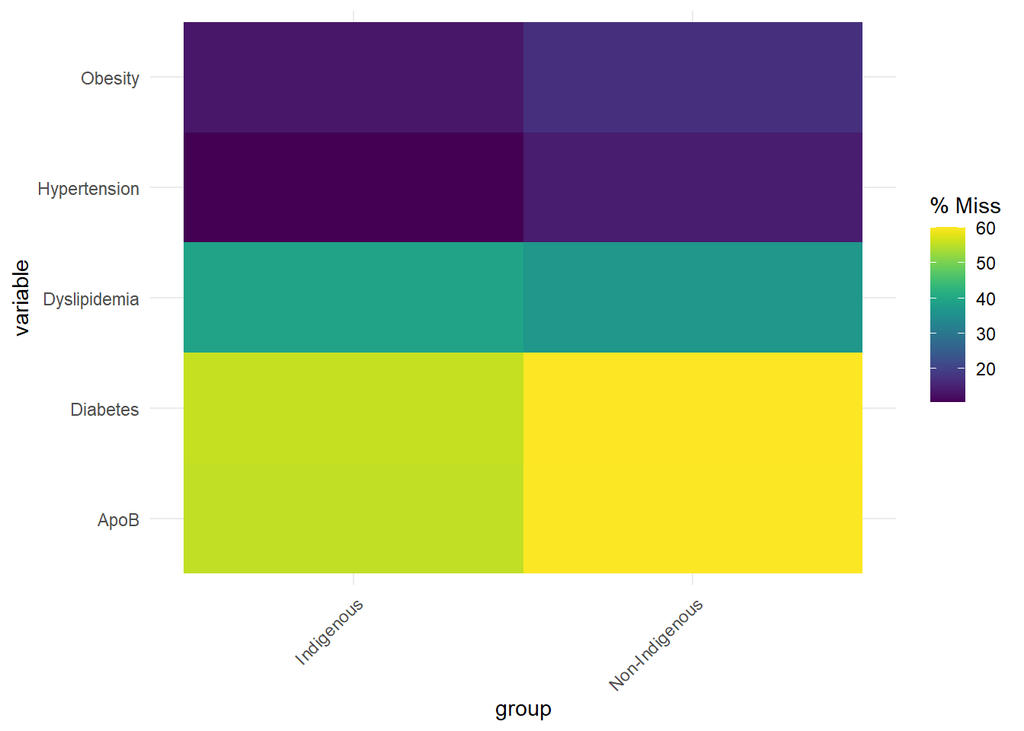

```
## [1] "Missingness for group: Indigenous"
```

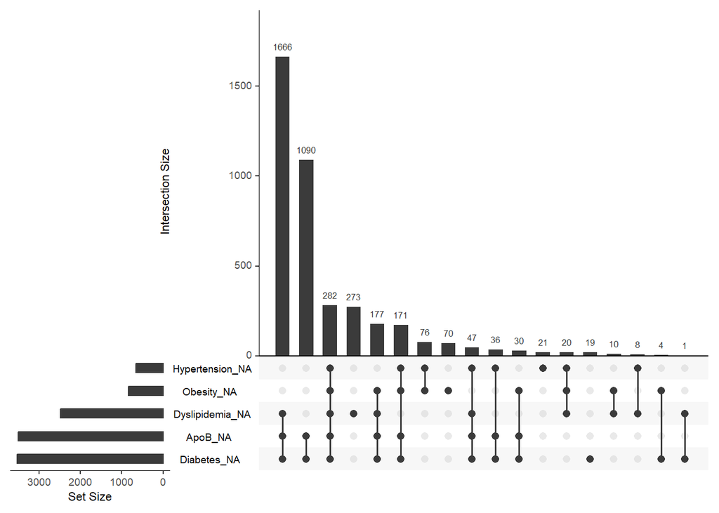

```
## [1] "Missingness for group: Non-Indigenous"
```

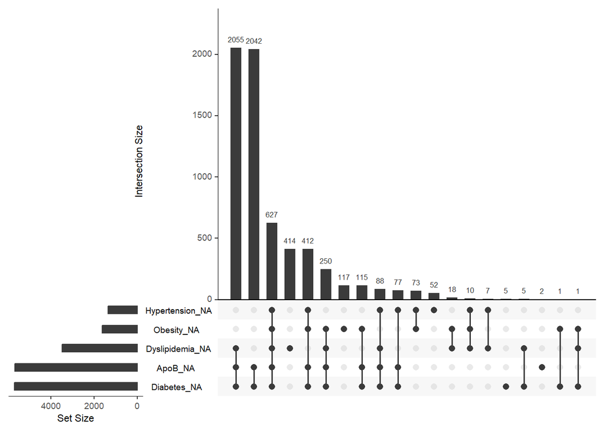

### 2.3.1 Dealing with NA values

Filter NA combinations (ApoB and Diabetes + ApoB and Diabetes and Dyslipidemia)

```r
filtered_cvd_df <- cvd_df %>%
  filter(
    !(is.na(ApoB) & is.na(Diabetes)), # Not both ApoB and Diabetes are NA
    !(is.na(ApoB) & is.na(Diabetes) & is.na(Dyslipidemia)) # Not all three variables are NA
  )
```

```
## [1] "Missingness for group: Indigenous"
```

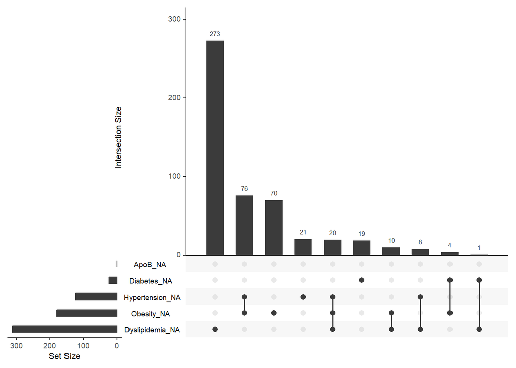

```
## [1] "Missingness for group: Non-Indigenous"
```

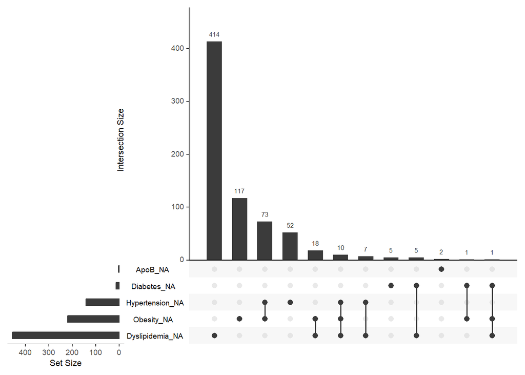

```
##
##     Indigenous Non-Indigenous
##           2803           3769
```

### 2.3.2 Group imbalance (downsampling)

```r
# Split data into Indigenous and Non-Indigenous
indigenous_df <- filter(filtered_cvd_df, group == "Indigenous")
nonindigenous_df <- filter(filtered_cvd_df, group == "Non-Indigenous")

# Randomly select 2500 samples from each group (couldve been 2800 to be more accurate)
sampled_indigenous <- sample_n(indigenous_df, 2500)
sampled_nonindigenous <- sample_n(nonindigenous_df, 2500)

# Combine the sampled datasets
sampled_df <- bind_rows(sampled_indigenous, sampled_nonindigenous)
# Convert all columns except ABSPID to factors
sampled_df[, -which(names(sampled_df) == "ABSPID")] <- lapply(sampled_df[, -which(names(sampled_df) == "ABSPID")], factor)

table(sampled_df$group)
```

```
##
##     Indigenous Non-Indigenous
##           2500           2500
```

## 2.4 Variables that have a signficantly different distribution in cohorts

Relevant variables for this analysis are factors with frequency counts. I assumed that our data is suitable for a Chi-squared test to determine if there is significant difference in high CVD risk prevalence between the two cohorts (Indigenous and Non-Indigenous Australians). Here is a barplot showing the proportion of high cvd risk prevalence by cohort:

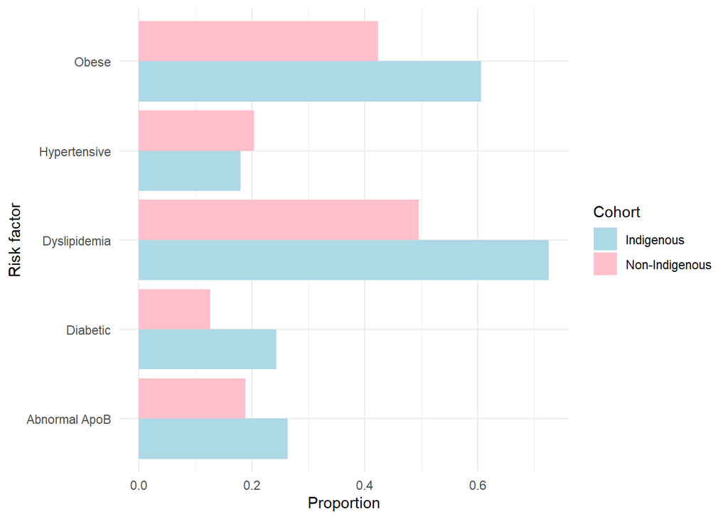

## 2.5 Statistical testing (Chi-Square)

```r
# Initialize an empty vector to store the significant variables
sig_vars <- c()
p_value_df <- data.frame(variable = character(), p_value = numeric())

for (var in cvd_vars) {
  # Subset the data
  x <- sampled_df %>% select(var, group)
  x[[var]] = as.factor(x[[var]])
  # If the variable is a factor, drop the specified levels and perform statistical testing
    # Perform Chi-squared test
    chisq_result <- chisq.test(table(x[[var]], x$group))
    p_value_df <- rbind(p_value_df, data.frame(variable = var, p_value = chisq_result$p.value))

    # If the p-value is less than 0.05, add the variable name to the sig_vars vector
    # not sure if i should have done a Bonferroni correction?
    if (chisq_result$p.value < 0.05) {
      sig_vars <- c(sig_vars, var)
    }
}

sorted_biom_p_df <- p_value_df %>% arrange(p_value)

# subset the original dataframe
sig_biom_final <- sampled_df %>% select(ABSPID, group, SEX, SMKDAILY, all_of(sig_vars))
biom_var_info = long_data
head(sorted_biom_p_df)
```

```
##       variable      p_value
## 1 Dyslipidemia 1.973386e-71
## 2      Obesity 9.113083e-41
## 3     Diabetes 1.269237e-26
## 4         ApoB 4.359646e-10
## 5 Hypertension 4.401522e-02
```

## 2.6 Saving/Clearing Environment

# 3 Dietary Patterns in Cohorts

## 3.1 Setup

### 3.1.1 Common data

```r
# get nutrition col names present in aboriginal df
nutr_ind = types_nutr$variable_name[types_nutr$variable_name %in% colnames(tech_abor)]
nutr_nonind = types_nutr$variable_name[types_nutr$variable_name %in% colnames(tech_nutr)]
names = intersect(nutr_ind, nutr_nonind)
# subset
ind_nutr = tech_abor %>% select(all_of(names)) %>% mutate(group = 'Indigenous')
nonind_nutr = tech_nutr %>% select(all_of(names)) %>% mutate(group = 'NonIndigenous')
# combine
df = rbind(ind_nutr, nonind_nutr)
df$group = as.factor(df$group)
dim(df)
```

```
## [1] 23516   192
```

### 3.1.2 Combining Day1 and Day2 measurements into an average

```r
# Initialize a list to store columns to be removed
cols_to_remove <- c()

# Loop through each column
for (col_name in colnames(df)) {
  # If the column name has a "1" or ends with "1N"
  if (grepl("1$", col_name) || grepl("1N$", col_name)) {
    # Determine the counterpart column name with "2"
    counterpart_col_name <- gsub("1$", "2", col_name)
    counterpart_col_name <- gsub("1N$", "2N", counterpart_col_name)

    # Check if both columns exist and if we haven't already processed them
    if (col_name %in% colnames(df) && counterpart_col_name %in% colnames(df) && !(col_name %in% cols_to_remove)) {
      # Calculate mean of both columns and assign to new column with suffix "_mean"
      mean_col_name <- paste0(gsub("[12]", "", col_name), "_mean")

      # Handle specific variables differently
      if (col_name %in% c("B12T1", "B12T2")) {
        mean_col_name <- ("B12_mean")
      } else if (col_name %in% c("B1T1", "B1T2")) {
        mean_col_name <- paste0("B1T_mean")
      } else if (col_name %in% c("B2T1", "B2T2")) {
        mean_col_name <- paste0("B2T_mean")
      } else if (col_name %in% c("B3T1", "B3T2")) {
        mean_col_name <- paste0("B3T_mean")
      } else if (col_name %in% c("B6T1", "B6T2")) {
        mean_col_name <- paste0("B6T_mean")
      }

      df[[mean_col_name]] <- rowMeans(df[, c(col_name, counterpart_col_name)], na.rm = TRUE)

      # Store columns to be removed
      cols_to_remove <- c(cols_to_remove, col_name, counterpart_col_name)
    }
  }
}

# Remove the original columns that had counterparts
df <- df[, !colnames(df) %in% cols_to_remove]
# PATCH 7
df = df %>% select(-ABSHID)


levels(df$group) <- c('Indigenous', 'NonIndigenous')
```

## 3.2 Checking equal variance and normality assumptions in data

### 3.2.1 QQPlots of variables that satisfy equal variance assumption (Levene’s test, p > 0.05)

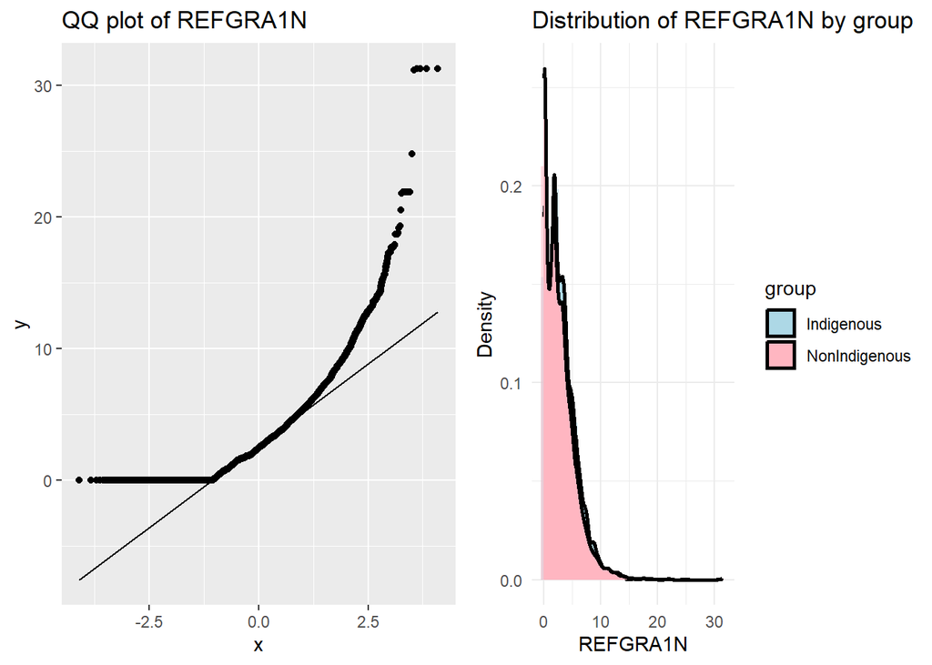

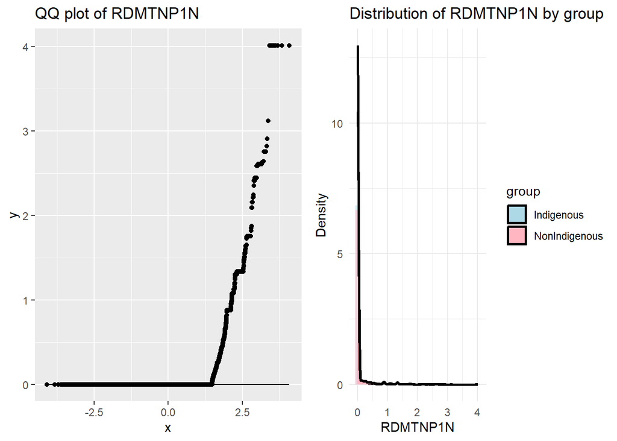

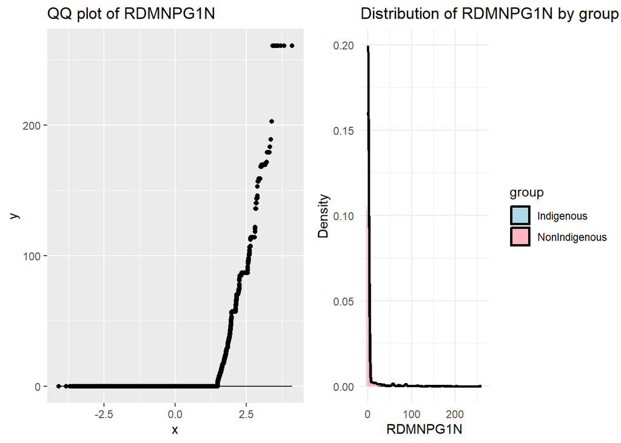

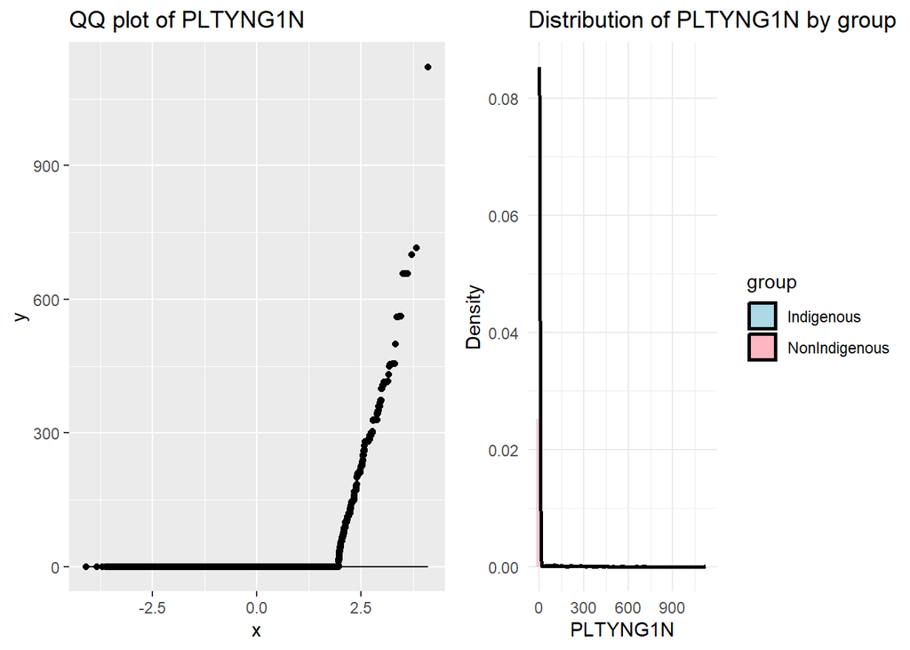

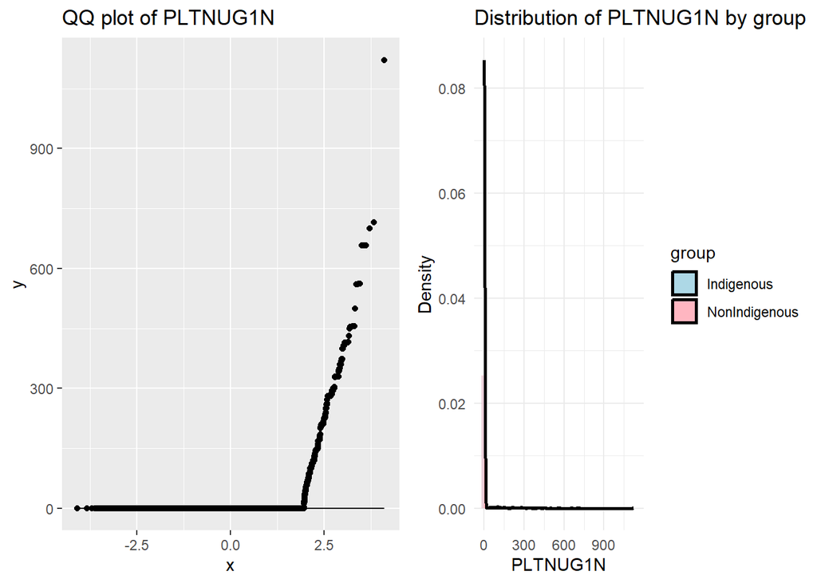

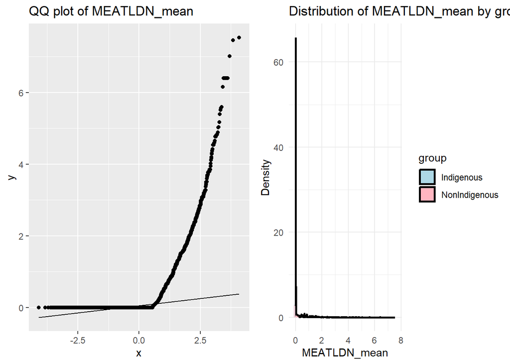

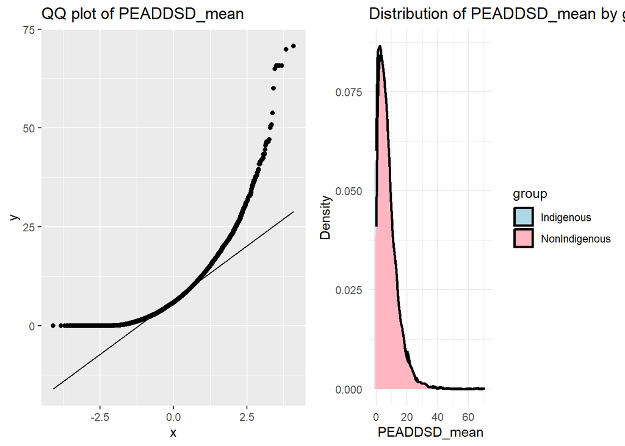

```r
plot_distribution <- function(df, var_name) {
  ggplot(df, aes_string(x = var_name, fill = "group")) +
    geom_histogram(aes(y = ..density..), position = "identity", alpha = 0.5, bins = 30) +
    geom_density(color = "black", lwd = 1) +
    labs(title = paste("Distribution of", var_name, "by group"), x = var_name, y = "Density") +
    theme_minimal() +
    scale_fill_manual(values = c("Indigenous" = "lightblue", "NonIndigenous" = "lightpink"))
}
variance_vars = c()
for (col in colnames(df)) {
  # Remove NA values for the current column
  df_temp <- df[!is.na(df[[col]]), ]

  # Test for homogeneity of variances
  if (is.numeric(df_temp[[col]])) {
    leveneTestRes <- leveneTest(df_temp[[col]], df_temp$group)
    # Check if the result is NA, and if not, then perform the comparison
    if (!is.na(leveneTestRes[1, "Pr(>F)"]) && leveneTestRes[1, "Pr(>F)"] > 0.05) {
      variance_vars = c(variance_vars, col)

      qq_plot <- ggplot(df_temp, aes(sample = .data[[col]])) +
        stat_qq() +
        stat_qq_line() +
        ggtitle(paste("QQ plot of", col))

      distribution_plot <- plot_distribution(df_temp, col)

      combined_plot <- grid.arrange(qq_plot, distribution_plot, ncol = 2)

    }
  }
}
```

### 3.2.2 Transformation

```
## function (...)
## UseMethod("var")
## <bytecode: 0x00000198646e2620>
## <environment: namespace:pROC>
```

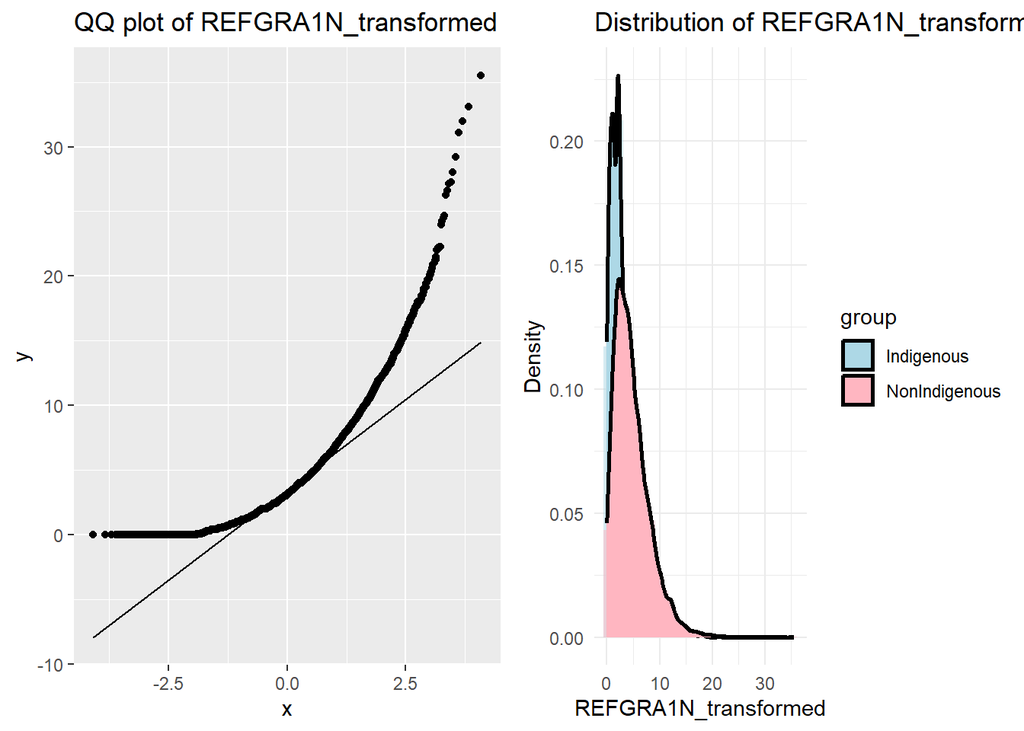

```
## function (...)
## UseMethod("var")
## <bytecode: 0x00000198646e2620>
## <environment: namespace:pROC>
```

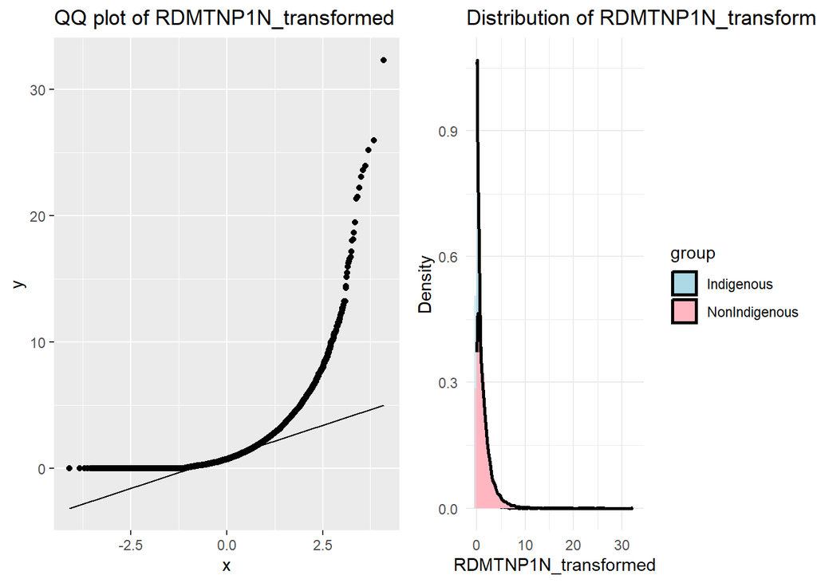

```
## function (...)
## UseMethod("var")
## <bytecode: 0x00000198646e2620>
## <environment: namespace:pROC>
```

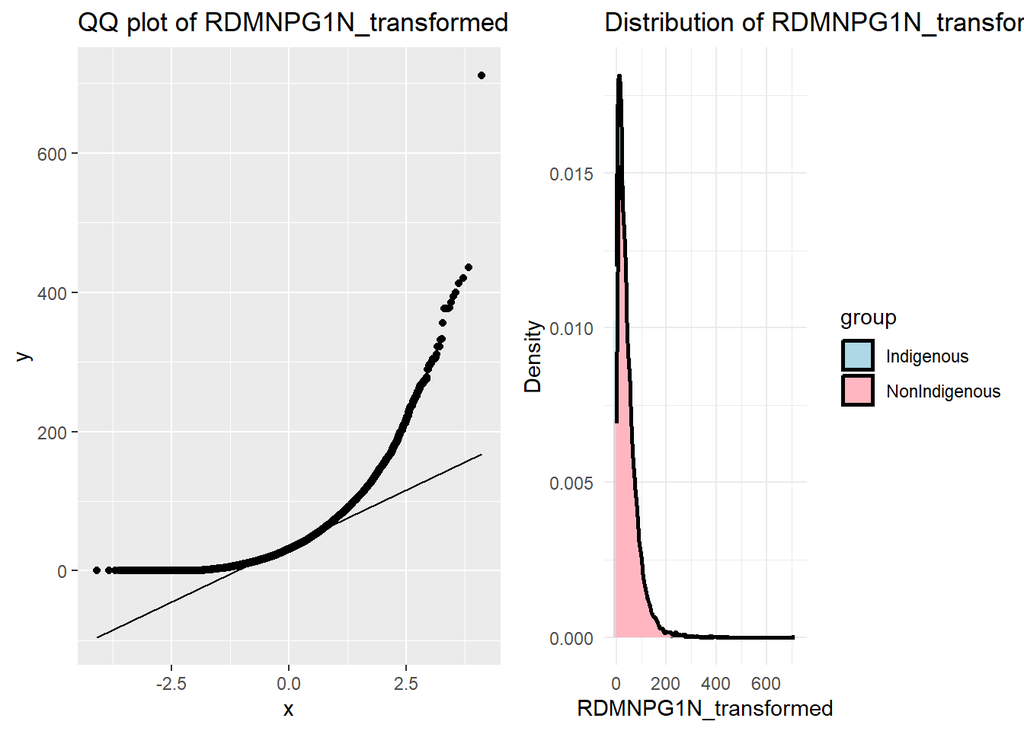

```
## function (...)
## UseMethod("var")
## <bytecode: 0x00000198646e2620>
## <environment: namespace:pROC>
```

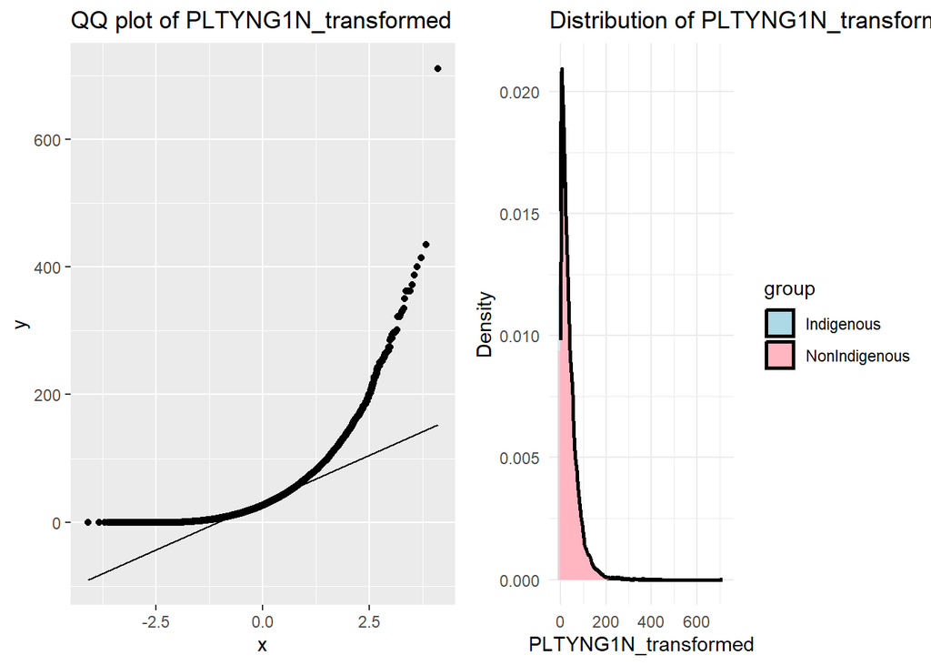

```
## function (...)
## UseMethod("var")
## <bytecode: 0x00000198646e2620>
## <environment: namespace:pROC>
```

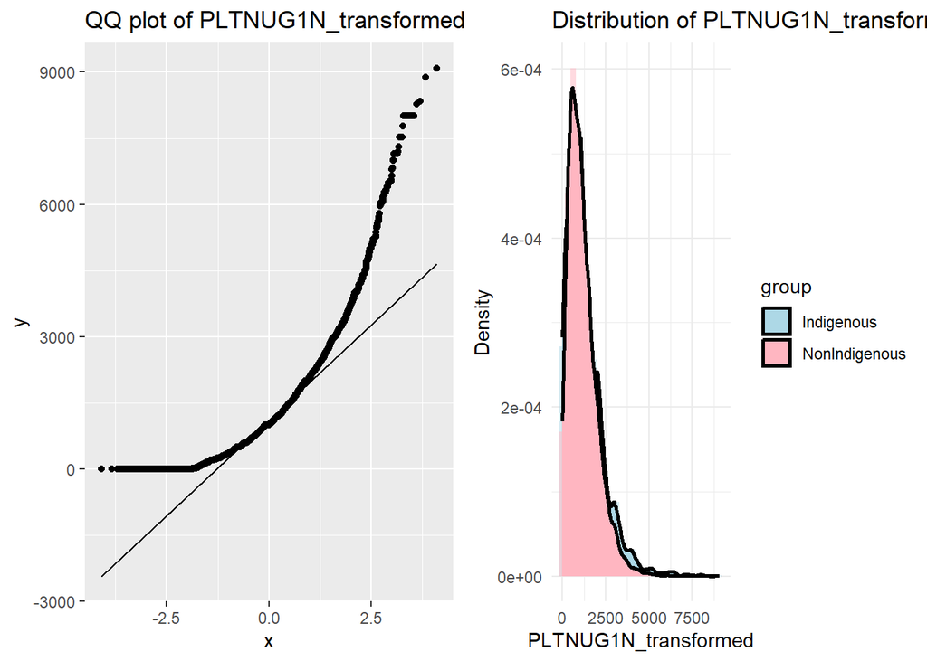

```
## function (...)
## UseMethod("var")
## <bytecode: 0x00000198646e2620>
## <environment: namespace:pROC>
```

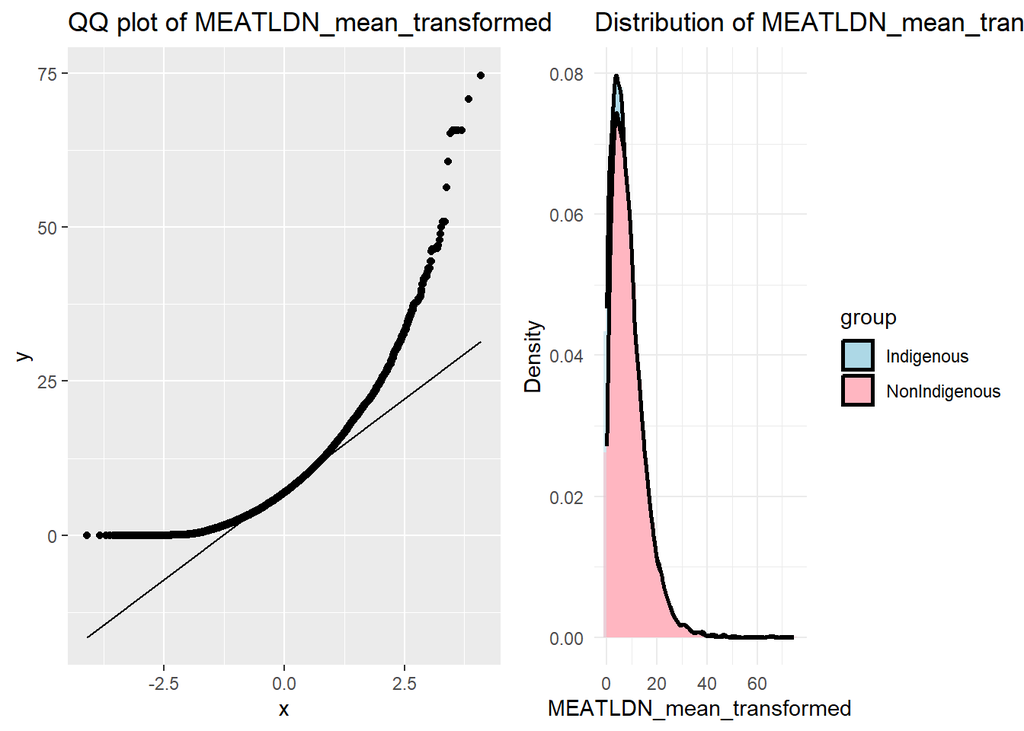

```
## function (...)
## UseMethod("var")
## <bytecode: 0x00000198646e2620>
## <environment: namespace:pROC>
```

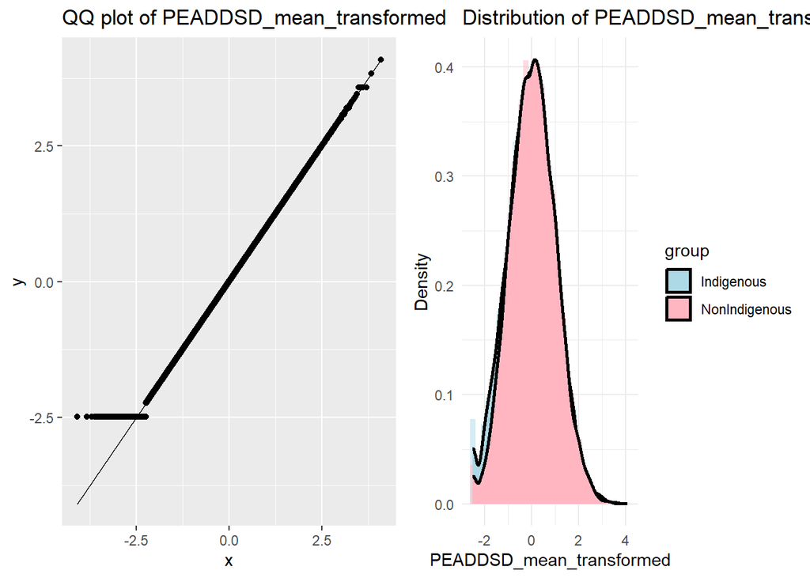

Only PEADDSD_mean satisfies both normality and variance assumptions. Further research indicated that the Kolmogorov-Smirnov test is appropriate:  
https://towardsdatascience.com/kolmogorov-smirnov-test-84c92fb4158d,  
https://en.wikipedia.org/wiki/Kolmogorov%E2%80%93Smirnov_test

## 3.3 KS test to find variables that have signficantly different distributions

```r
# Initialize a list to store p-values
ks_test_results <- list()
test_cols <- setdiff(colnames(df), c("ABSPID", "group"))
for (col in test_cols) {
  # Extract non-NA values for the current column
  df_temp <- df[!is.na(df[[col]]), ]

  group_ind_values <- df_temp[[col]][df_temp$group == "Indigenous"]
  group_nonind_values <- df_temp[[col]][df_temp$group == "NonIndigenous"]

  # Perform the Kolmogorov-Smirnov test
  test_result <- ks.test(group_ind_values, group_nonind_values)

  # Store p-value
  ks_test_results[[col]] <- test_result$p.value
}

# Order variables by p-values
ordered_vars_ks <- names(ks_test_results)[order(unlist(ks_test_results))]

# Print variables with p-values less than 0.01
significant_vars_ks <- ordered_vars_ks[unlist(ks_test_results)[order(unlist(ks_test_results))] < 0.01]
sig_nutr_final = df %>% select(ABSPID, group, significant_vars_ks)

# Initialize an empty dataframe
summary_df <- data.frame(Variable = character(0), Indigenous = numeric(0), NonIndigenous = numeric(0), P_Value = numeric(0))

# Loop through the variables from KS test results
for (col in ordered_vars_ks) {
  # Extract non-NA values for the current column
  df_temp <- df[!is.na(df[[col]]), ]

  # Calculate medians for the two groups
  Indigenous <- median(df_temp[[col]][df_temp$group == "Indigenous"], na.rm = TRUE)
  NonIndigenous <- median(df_temp[[col]][df_temp$group == "NonIndigenous"], na.rm = TRUE)

  # Extract p-value
  p_val <- ks_test_results[[col]]

  # Append to the summary dataframe
  summary_df <- rbind(summary_df, data.frame(Variable = col, Indigenous = Indigenous, NonIndigenous = NonIndigenous, P_Value = p_val))
}

# View the summary dataframe
summary_df = summary_df %>% filter(P_Value < 0.01)




# Use labels from dictionary to understand values

cols_to_remove <- c()
mean_col_names = c()
mean_col_descs = c()
df1 = list()
i = 1
# Loop through each column
for (col_name in types_nutr$variable_name) {
  # If the column name has a "1"
  if (grepl("1$", col_name) || grepl("1N$", col_name)) {
    # Determine the counterpart column name with "2"
    counterpart_col_name <- gsub("1$", "2", col_name)
    counterpart_col_name <- gsub("1N$", "2N", counterpart_col_name)

    # Check if both columns exist and if we haven't already processed them
    if (col_name %in% types_nutr$variable_name && counterpart_col_name %in% types_nutr$variable_name && !(col_name %in% cols_to_remove)) {
            # Handle specific variables differently
      if (col_name %in% c("B12T1", "B12T2")) {
          mean_col_name <- ("B12_mean")
          mean_col_desc = types_nutr$description[i]
        } else if (col_name %in% c("B1T1", "B1T2")) {
          mean_col_name <- paste0("B1T_mean")
          mean_col_desc = types_nutr$description[i]
        } else if (col_name %in% c("B2T1", "B2T2")) {
          mean_col_name <- paste0("B2T_mean")
          mean_col_desc = types_nutr$description[i]
        } else if (col_name %in% c("B3T1", "B3T2")) {
          mean_col_name <- paste0("B3T_mean")
          mean_col_desc = types_nutr$description[i]
        } else if (col_name %in% c("B6T1", "B6T2")) {
          mean_col_name <- paste0("B6T_mean")
          mean_col_desc = types_nutr$description[i]
        }
      else {
        mean_col_name <- paste0(gsub("[12]", "", col_name), "_mean")
        mean_col_desc = types_nutr$description[i]
      }
      df1 = rbind(df1, c(mean_col_name, mean_col_desc))
      # Store columns to be removed
      cols_to_remove <- c(cols_to_remove, col_name, counterpart_col_name)
    }
  }
  if(!(col_name %in% cols_to_remove)){
    unique_col_desc = types_nutr$description[i]
    df1 = rbind(df1, c(col_name, unique_col_desc))
  }
  i = i + 1

}
df1 = as.data.frame(df1)
df1$V1 = as.character(df1$V1)
df1$V2 = as.character(df1$V2)
df1$V2 = gsub("(?i)day\\s*1|\\s+", " ", df1$V2)

final = summary_df %>%
  left_join(df1, by = c("Variable" = "V1"))
final = summary_df %>%
  left_join(df1, by = c("Variable" = "V1"))
final = final %>% mutate(diff = abs(Indigenous - NonIndigenous)) %>% filter(Indigenous != 0, NonIndigenous != 0)
```

## 3.4 Visualisation

### 3.4.1 All variables grouped by category, shown by median (robust measure when considering distributions)

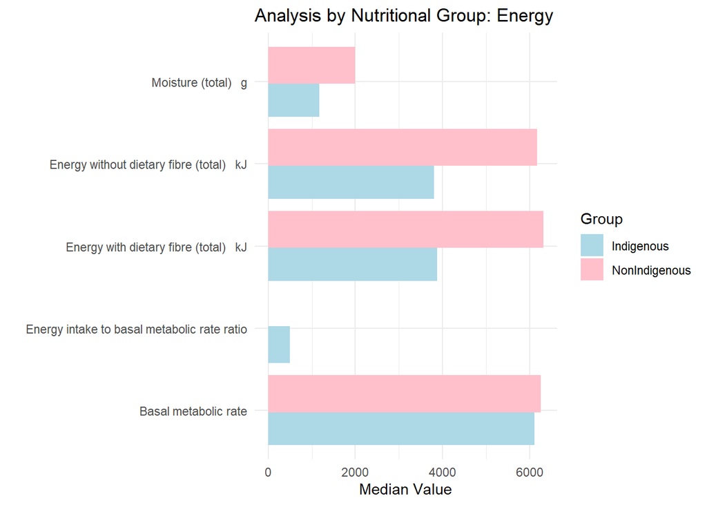

```r
# Energy
energy_vars <- c("BMR", "EIBMR_mean", "ENERGYT_mean", "ENRGYT_mean", "MOISTT_mean")

# Macronutrients
macronutrient_vars <- c("PROTT_mean", "FATT_mean", "CHOWSAT_mean", "CHOWOAT_mean", "STARCHT_mean",
                        "SUGART_mean", "FIBRET_mean")

# Vitamins
vitamin_vars <- c("PREVAT_mean", "PROVAT_mean", "RETEQT_mean", "B1T_mean", "B2T_mean",
                  "B3T_mean", "NIACINT_mean", "FOLATT_mean", "FOLICT_mean", "TOTFOLT_mean",
                  "FOLEQT_mean", "B6T_mean", "B12_mean", "VITCT_mean", "VITET_mean")

# Minerals
mineral_vars <- c("CALCT_mean", "IODINET_mean", "IRONT_mean", "MAGT_mean", "PHOST_mean",
                  "POTAST_mean", "SELT_mean", "SODIUMT_mean", "ZINCT_mean")

# Fats
fat_vars <- c("CAFFT_mean", "CHOLT_mean", "SATFATT_mean", "MUFATT_mean", "PUFATT_mean",
              "LAT_mean", "ALAT_mean", "LCN3T_mean", "TRANST_mean")

# Percentage of Energy from Macronutrients
energy_percentage_vars <- c("PROPER_mean", "FATPER_mean", "LAPER_mean", "ALAPER_mean",
                            "CHOPER_mean", "SUGPER_mean", "STARPER_mean", "SATPER_mean",
                            "TRANPER_mean", "FIBRPER_mean", "MONOPER_mean", "POLYPER_mean", "PEFRESD_mean", "PEADDSD_mean")

energy_percentage_vars1 <-
  c( "FATPER_mean",  "CHOPER_mean", "SUGPER_mean",  "FIBRPER_mean", "PEADDSD_mean")


# Food Groups
food_groups_vars <- c("GRAINSN_mean", "VEGLEGN_mean", "FRUITN_mean", "DAIRYN_mean", "MEATN_mean", "MEATLN_mean",
                      "WATERN_mean", "UNSATN_mean")

food_groups_vars1 <- c("GRAINSN_mean", "VEGLEGN_mean", "FRUITN_mean",  "MEATN_mean","WATERN_mean", "UNSATN_mean")
# Others
other_vars <- c("FRESUGN_mean", "ADDSUGN_mean", "WATERGN_mean")

# Grouping all variables
group_names <- c('energy_vars', 'macronutrient_vars', 'vitamin_vars', 'mineral_vars', 'fat_vars',
                   'energy_percentage_vars', 'food_groups_vars', 'other_vars')



plot_nutrient_group <- function(data, nutrient_group, name) {

  # Reshape the dataframe to long format for plotting
  data_long <- data %>%
    gather(key = "Group", value = "Median", Indigenous, NonIndigenous)

  # Filter data based on the nutrient group provided
  df_group <- data_long[data_long$Variable %in% nutrient_group, ]

  # Remove the '()' from the V2 variable
  df_group$V2 <- gsub("\\s*\\(.*\\)\\s*$", "", df_group$V2)

  # Plot
  p <- ggplot(df_group, aes(x = V2, y = Median, fill = Group)) +
    geom_bar(stat = "identity", position = position_dodge(width = 0.8)) +
    coord_flip() +
    labs(title = paste0("Analysis by Nutritional Group: ", name), y = "Median Value", x = "") +
    theme_minimal() +
    scale_fill_manual(values = c("Indigenous" = "lightblue", "NonIndigenous" = "pink"))


  return(p)
}

plot_nutrient_group(final, energy_vars, "Energy")
```

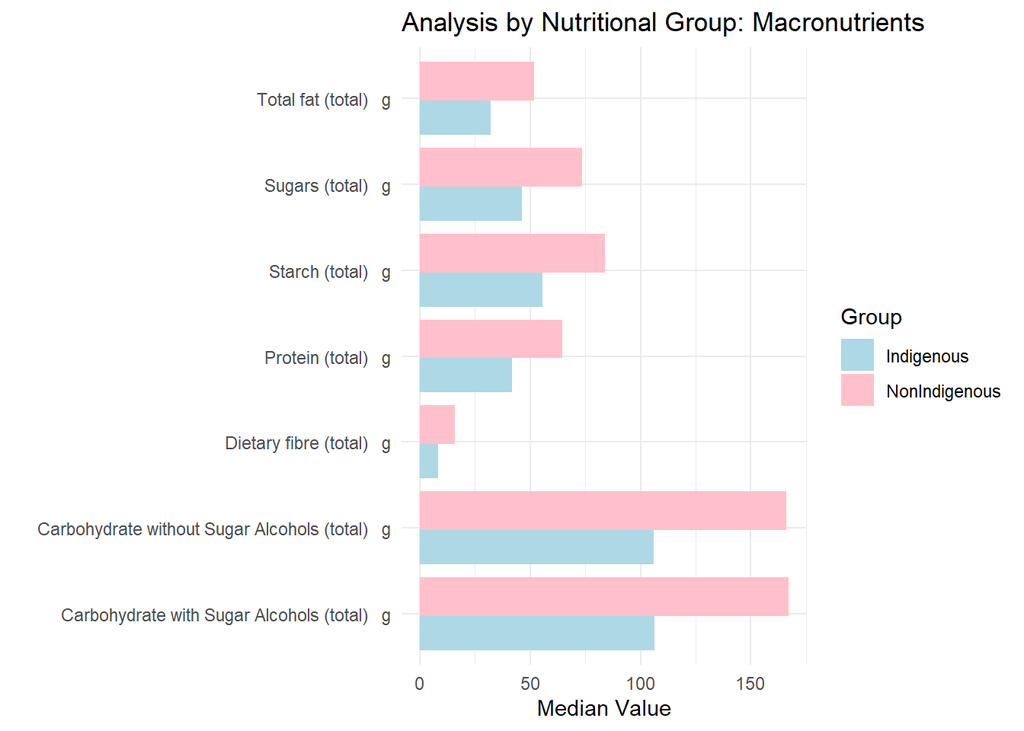

```r
plot_nutrient_group(final, macronutrient_vars, "Macronutrients")
```

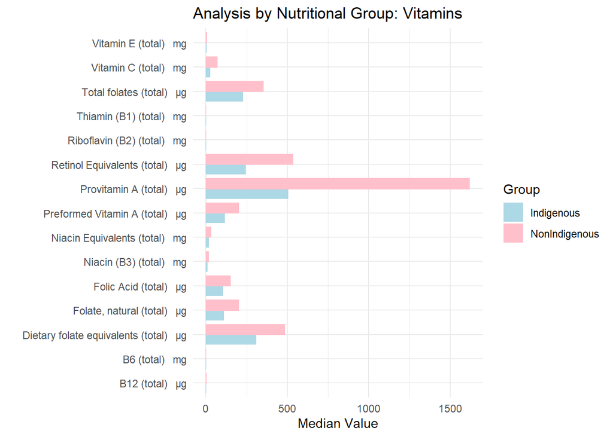

```r
plot_nutrient_group(final, vitamin_vars, "Vitamins")
```

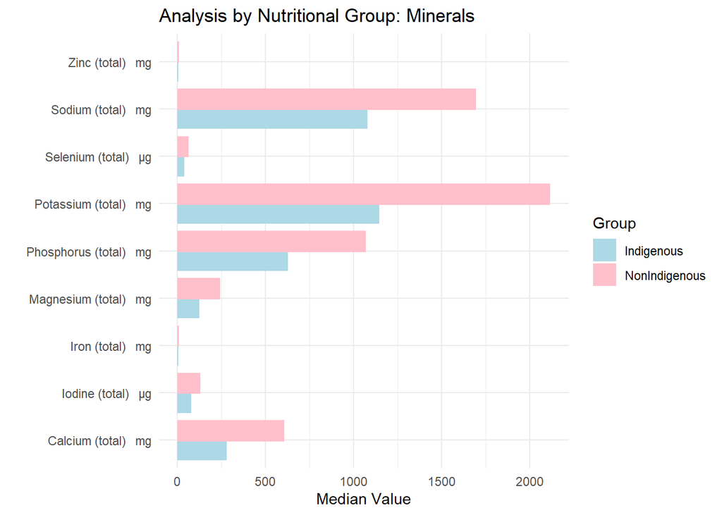

```r
plot_nutrient_group(final, mineral_vars, "Minerals")
```

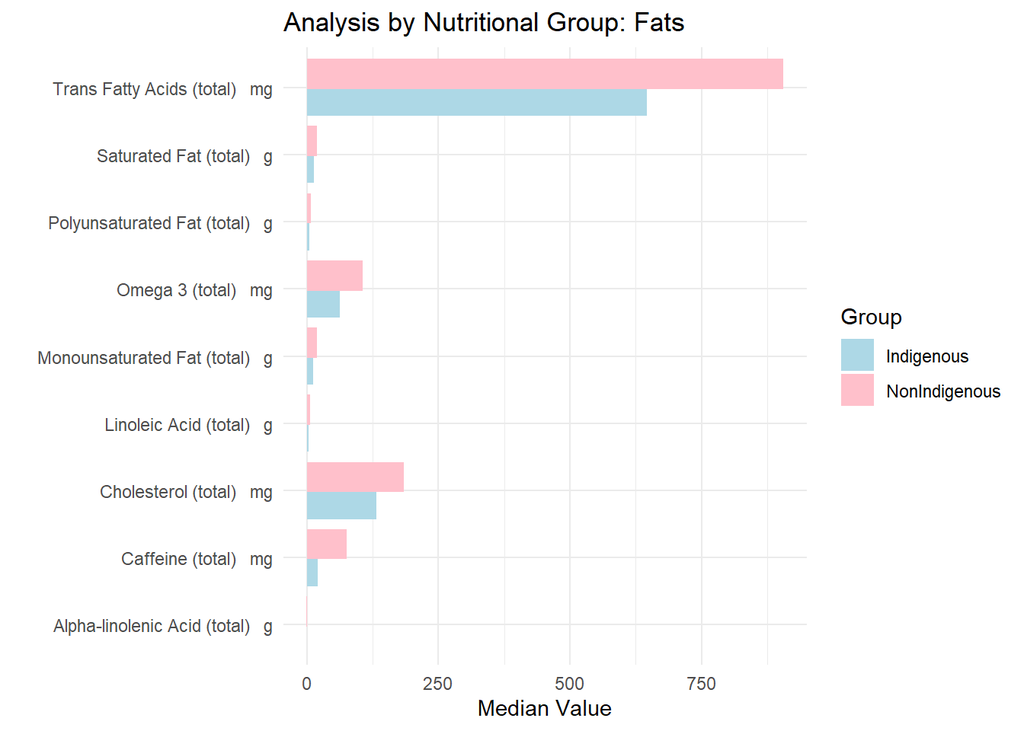

```r
plot_nutrient_group(final, fat_vars, "Fats")
```

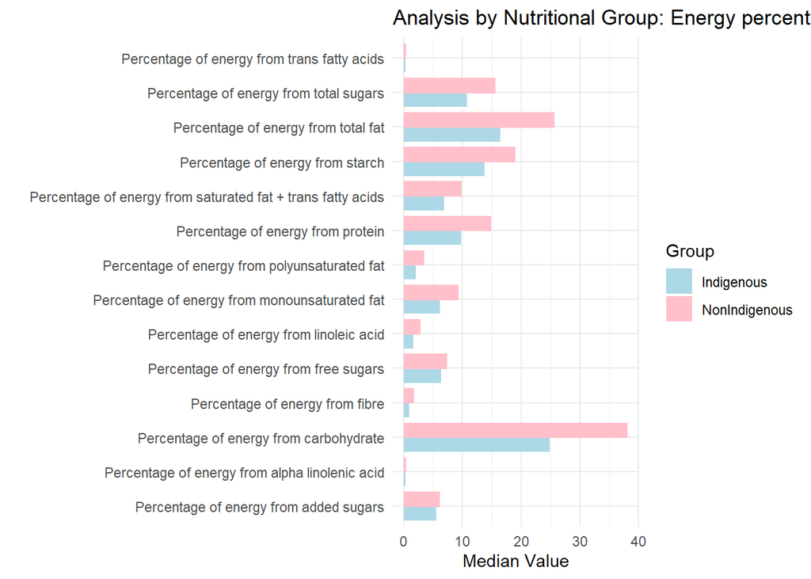

```r
plot_nutrient_group(final, energy_percentage_vars, "Energy percentages")
```

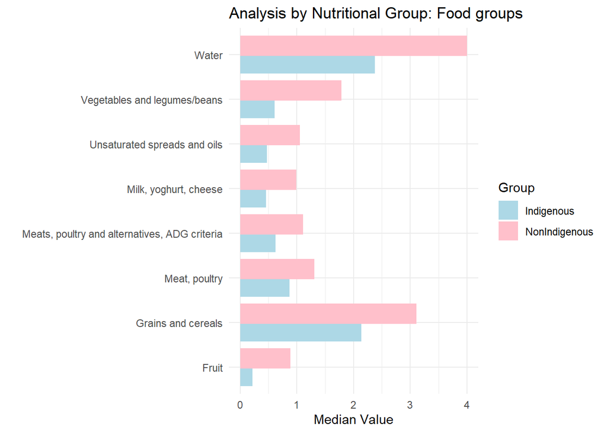

```r
plot_nutrient_group(final, food_groups_vars, "Food groups")
```

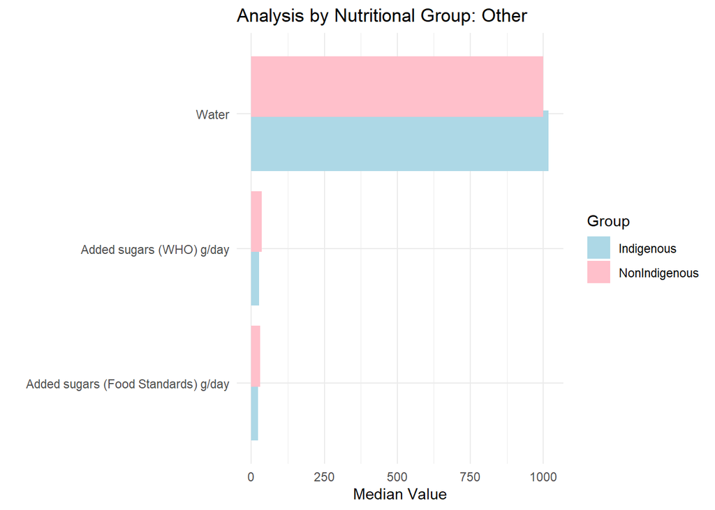

```r
plot_nutrient_group(final, other_vars, "Other")
```

### 3.4.2 Boxplots showing distributions of relevant variables in analysis

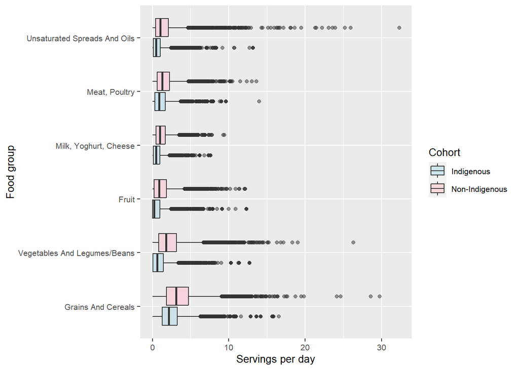

```r
foods = c("GRAINSN_mean", "VEGLEGN_mean", "FRUITN_mean", "DAIRYN_mean", "MEATN_mean", "UNSATN_mean")

energypers =  c("FATPER_mean",  "PROPER_mean", "CHOPER_mean", "SUGPER_mean",  "FIBRPER_mean", "PEADDSD_mean", "SATPER_mean")

df$group = gsub("NonIndigenous", "Non-Indigenous", df$group)

id_desc <- final %>%
  mutate(name = gsub("\\s*\\(.*\\)\\s*$", "", V2) %>%  # remove "()"
           gsub(".*\\bfrom\\s+", "", .) %>%  # remove '...from'
           str_to_title(.)) %>%  # capitalize
  select(Variable, name)

food_labels = id_desc %>% filter(Variable %in% foods)
energy_labels = id_desc %>% filter(Variable %in% energypers)


df_longf <- gather(df, key = "variable", value = "value", foods)
df_longf = df_longf %>% mutate
df_longe <- gather(df, key = "variable", value = "value", energypers)

ggplot(df_longf, aes(x = variable, y = value, fill = group)) +
  geom_boxplot(alpha = 0.5) +
  coord_flip() +
  scale_fill_manual(values = c("lightblue", "pink"), name = "Cohort")  +
  scale_x_discrete(limits = food_labels$Variable, labels = food_labels$name) +
  labs(x = "Food group", y = "Servings per day", fill = "Group")+
  theme(text = element_text(size=10))
```

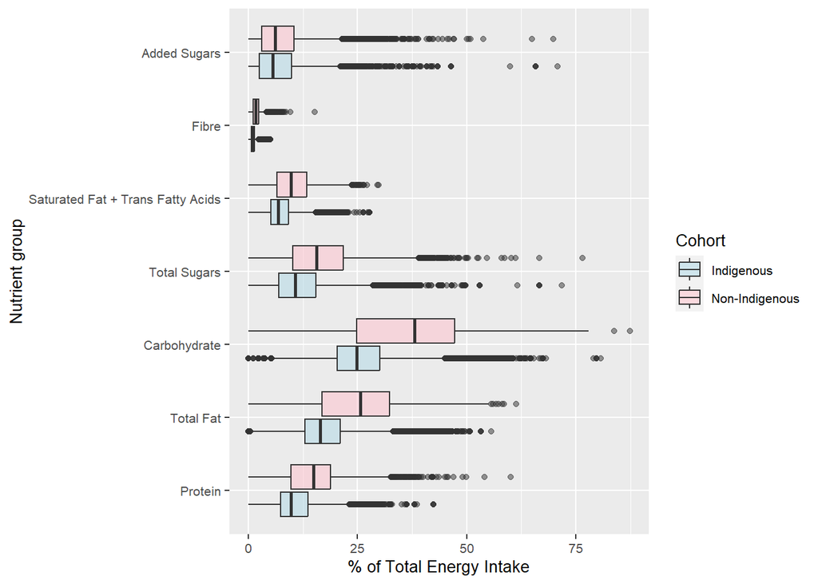

```r
ggplot(df_longe, aes(x = variable, y = value, fill = group)) +
  geom_boxplot(alpha = 0.5) +
  coord_flip() +
  scale_fill_manual(values = c("lightblue", "pink"), name = "Cohort") +
  scale_x_discrete(limits = energy_labels$Variable, labels = energy_labels$name) +
  labs(x = "Nutrient group", y = "% of Total Energy Intake", fill = "Group") +
  theme(text = element_text(size=10))
```

## 3.5 Saving/Clearing Environment

# 4 Associating Diet to CVD Risk in Cohorts

## 4.1 Setup and Definitions

```r
cvdnutr <- sig_biom_final %>%
            left_join(sig_nutr_final %>% select(-group), by = "ABSPID")

# Lets define high risk cvd as satisfying at least two of the CVD criteria (Nutrition students):

cvdnutr$cvd_risk <- ifelse(
  (
      ifelse(!is.na(cvdnutr$Obesity) & cvdnutr$Obesity == "Obese", 1, 0) +
      # ifelse(!is.na(cvdnutr$Hypertension) & cvdnutr$Hypertension == "Hypertensive", 1, 0) +
      ifelse(!is.na(cvdnutr$Diabetes) & cvdnutr$Diabetes == "Diabetic", 1, 0) +
      ifelse(!is.na(cvdnutr$ApoB) & cvdnutr$ApoB == "Abnormal ApoB", 1, 0) +
      ifelse(!is.na(cvdnutr$Dyslipidemia) & cvdnutr$Dyslipidemia== "Dyslipidemia", 1, 0)) >= 2, "high", "low")
      #  + ifelse(!is.na(cvdnutr$SMKDAILY) & cvdnutr$SMKDAILY %in% c("1. Current daily smoker", "2. Past daily smoker (still smokes)"), 1, 0)

table(cvdnutr$cvd_risk, cvdnutr$group)
```

```
##
##        Indigenous Non-Indigenous
##   high       1418            839
##   low        1082           1661
```

### 4.1.1 Dietary ranges

```r
# Define risk categories in dietary variables (Nutrition students)

cvdnutrdf = cvdnutr %>% mutate(
  Vegetables_Legumes_beans = case_when(
    VEGLEGN_mean < 5.5 ~ '< 5.5',
    VEGLEGN_mean > 5.5 ~ '≥ 5.5',TRUE ~ NA_character_),
  Fruit = case_when(
    FRUITN_mean < 2 ~ '< 2 ',
    FRUITN_mean >= 2 ~ '≥ 2 ',TRUE ~ NA_character_),
  Grains_cereals = case_when(
    GRAINSN_mean < 6 ~ '< 6 ',
    GRAINSN_mean >= 6 ~ '≥ 6 ',TRUE ~ NA_character_),
  Meat_Poultry = case_when(
    MEATN_mean < 2.5 ~ '< 2.5 ',
    MEATN_mean >= 2.5 ~ '≥ 2.5 ',TRUE ~ NA_character_),
  Dairy = case_when(
    DAIRYN_mean < 2.5 ~ '< 2.5 ',
    DAIRYN_mean >= 2.5 ~ '≥ 2.5 ',TRUE ~ NA_character_),
  Unsaturated_Spread_Oils = case_when(
    UNSATN_mean < 4 ~ '< 4 ',
    UNSATN_mean >= 4 ~ '≥ 4 ',TRUE ~ NA_character_),
  FreeSugar = case_when(
    UNSATN_mean < 10 ~ '< 10 %',
    UNSATN_mean >= 10 ~ '≥ 10 %',TRUE ~ NA_character_),
  TotalFat = case_when(
    FATPER_mean < 30 ~ '< 30 %',
    FATPER_mean >= 30 ~ '≥ 30 %',TRUE ~ NA_character_),
  Carbohydrates = case_when(
    CHOPER_mean <= 40 ~ '≤ 40 %',
    CHOPER_mean > 40 & CHOPER_mean < 70 ~ '40 -70 %',
    CHOPER_mean >= 70 ~ '≥ 70 %',TRUE ~ NA_character_),
  Protein = case_when(
    PROPER_mean <= 15 ~ '< 15 %',
    CHOPER_mean > 15 & CHOPER_mean < 25 ~ '15 -25 %',
    CHOPER_mean >= 25 ~ '≥ 25 %',TRUE ~ NA_character_),
  SaturatedTransFat = case_when(
    SATPER_mean < 11 ~ '< 11 %',
    SATPER_mean >= 11 ~ '≥ 11 %',TRUE ~ NA_character_),
  DietaryFibre = case_when(
    FIBRET_mean < 30 ~ '< 30 g',
    FIBRET_mean >= 30 ~ '≥ 30 g',TRUE ~ NA_character_),
  cvd_risk_stat = ifelse(cvdnutr$cvd_risk == 'high', 1, 0)) %>%
  select(c(colnames(sig_biom_final), Vegetables_Legumes_beans, Fruit, Grains_cereals, Meat_Poultry, Dairy, Unsaturated_Spread_Oils, FreeSugar, TotalFat, Carbohydrates, Protein, SaturatedTransFat, DietaryFibre, cvd_risk, cvd_risk_stat))
```

## 4.2 Preliminary regression model

Build preliminary regression model (in our presentation)

```r
# Split the data into training and test sets (70% training, 30% test)
splitIndex <- createDataPartition(cvdnutr$cvd_risk, p = .7, list = FALSE)
train_data <- cvdnutr[splitIndex, ]
test_data <- cvdnutr[-splitIndex, ]
train_data$cvd_risk <- ifelse(train_data$cvd_risk == "high", 1, 0)
test_data$cvd_risk <- ifelse(test_data$cvd_risk == "high", 1, 0)

# Get nutrition variable names
nutr_vars <- setdiff(colnames(sig_nutr_final), c("ABSPID", "group"))

# Fit the model
model_diet <- glm(cvd_risk ~ .,
                   data = train_data %>% select(cvd_risk, all_of(nutr_vars), group),
                   family = "binomial")


# Extract coefficients from the model
coef_summary <- summary(model_diet)$coefficients

# Predict probabilities
probabilities <- predict(model_diet, type = "response", newdata = test_data)

# Convert to binary prediction based on a threshold (0.5 is common)
predicted_values <- ifelse(probabilities > 0.5, 1, 0)

# ROC curve
roc_obj <- roc(test_data$cvd_risk, probabilities)
auc(roc_obj)
```

```
## Area under the curve: 0.646
```

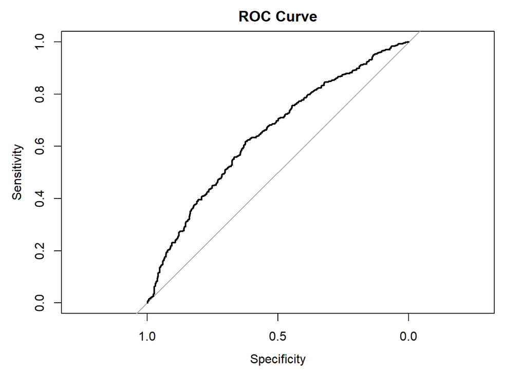

```r
plot(roc_obj, main="ROC Curve")
```

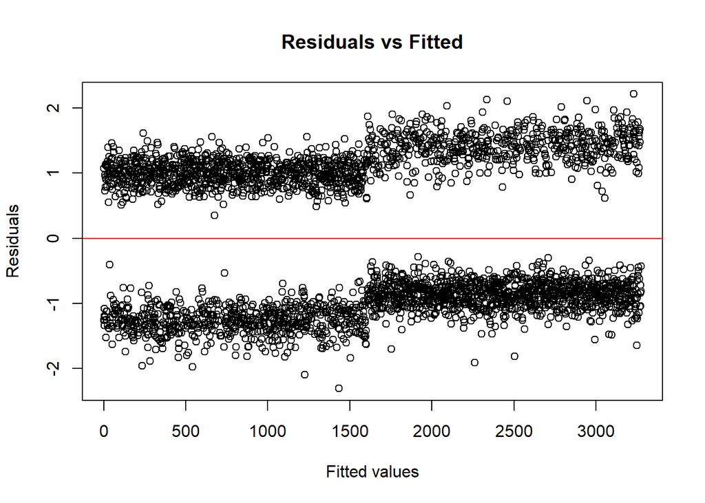

```r
# Plot residuals
plot(residuals(model_diet), main="Residuals vs Fitted", xlab="Fitted values", ylab="Residuals")
abline(h = 0, col = "red")
```

```r
# Generate confusion matrix
cm <- confusionMatrix(as.factor(predicted_values), as.factor(test_data$cvd_risk))

# Print the confusion matrix and related statistics
print(cm)
```

```
## Confusion Matrix and Statistics
##
##           Reference
## Prediction   0   1
##          0 506 300
##          1 244 346
##
##                Accuracy : 0.6103
##                  95% CI : (0.5842, 0.636)
##     No Information Rate : 0.5372
##     P-Value [Acc > NIR] : 2.16e-08
##
##                   Kappa : 0.2115
##
##  Mcnemar's Test P-Value : 0.01837
##
##             Sensitivity : 0.6747
##             Specificity : 0.5356
##          Pos Pred Value : 0.6278
##          Neg Pred Value : 0.5864
##              Prevalence : 0.5372
##          Detection Rate : 0.3625
##    Detection Prevalence : 0.5774
##       Balanced Accuracy : 0.6051
##
##        'Positive' Class : 0
##
```